# Reproducing ArchaeoPhases Objects

Thomas S. Dye

2022-06-21

# 4. ArchaeoPhases : Reproducibility

## Introduction

Version `ArchaeoPhases 1.5` adds new read, plot, and statistical functions designed to encourage reproducibility. This vignette describes some of these functions and illustrates how to use them to reproduce an analysis.

New read functions `read_bcal()`, `read_oxcal()`, and `read_chronomodel()` are intended to replace the general purpose function, `ImportCSV()`. The new functions are built on the function `read_csv()`, which is fast and able to read remote files, as well as local files. The new functions return S3 objects that can identify the file that produced them. This facility might be useful in situations where an analysis is based on a remote file that isn’t under the analyst’s control, or when files are shared electronically and potentially subject to corruption.

## Test for Original Data File

```r
## load ArchaeoPhases
library(ArchaeoPhases)
## read remote file
data(oxc)
## returns TRUE, if ox.csv has not changed on the server
original_file(oxc)
```

```
[1] TRUE
```

## New Plot Functions

The new plot functions, `multi_dates_plot()`, `tempo_activity_plot()`, `tempo_plot()`, `marginal_plot()`, `multi_marginal_plot()`, and `occurrence_plot()` are functional replacements for the originals with camelCase names, e.g., `TempoPlot()` -> `tempo_plot()`. They return S3 objects with `plot()` and `reproduce()` methods that inherit from data frame and can be passed to statistical functions.

The following code block illustrates the `plot()` and `reproduce()` methods. The call to the `marginal_plot` function draws a plot of the first marginal posterior in the `oxc` object and returns an S3 object, which is assigned to the variable `oxc.mar`. The call to the `plot` method of the `oxc.mar` object draws the same plot and also returns an S3 object. Note that the S3 objects returned by `marginal_plot()` and `plot()` differ because the calls that created them differ. Nevertheless, the data returned by the two calls are identical, as expected. The call, `reproduce(oxc.mar)` checks that the original file is accessible and has not changed, then recreates the plot. If successful, the object it returns is identical with the object it reproduces.

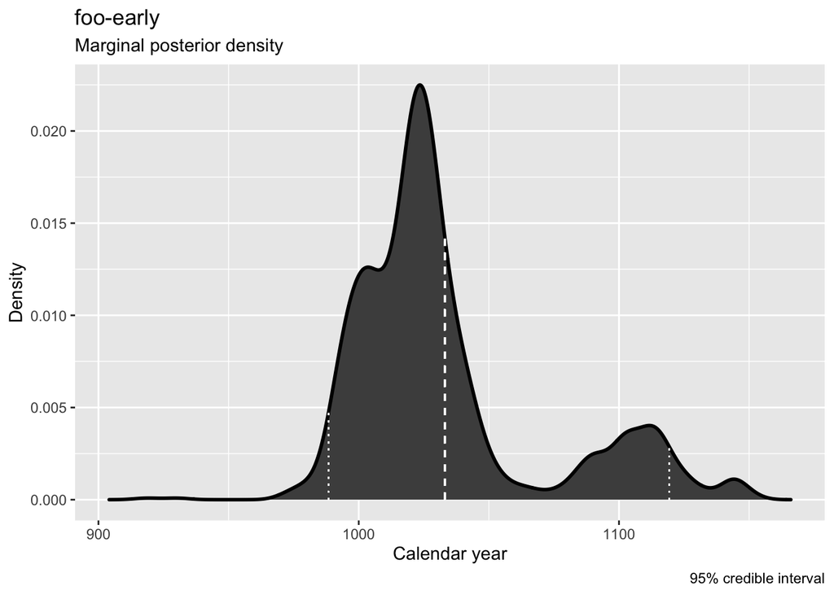

```r
## create mariginal plot object
oxc.mar <- marginal_plot(oxc)
```

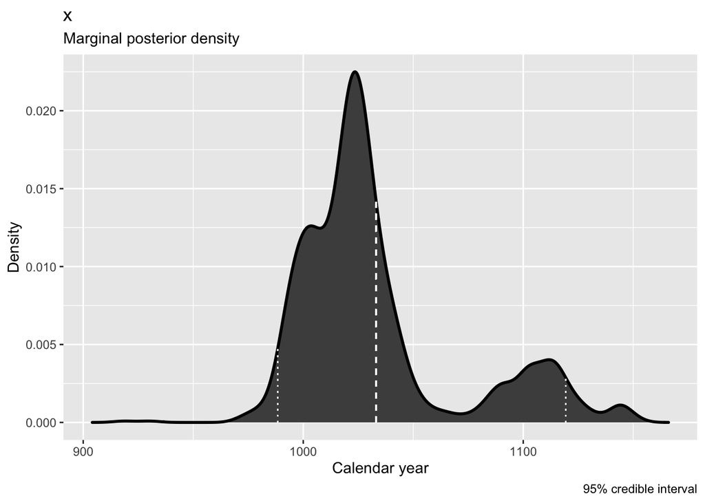

```r
## use plot method to reproduce marginal plot
oxc.mar.plot <- plot(oxc.mar)
```

```r
## check for identity returns FALSE because calls differ
identical(oxc.mar, oxc.mar.plot)
```

```
[1] FALSE
```

```r
## check for data identity returns TRUE
identical(oxc.mar$x, oxc.mar.plot$x)
```

```
[1] TRUE
```

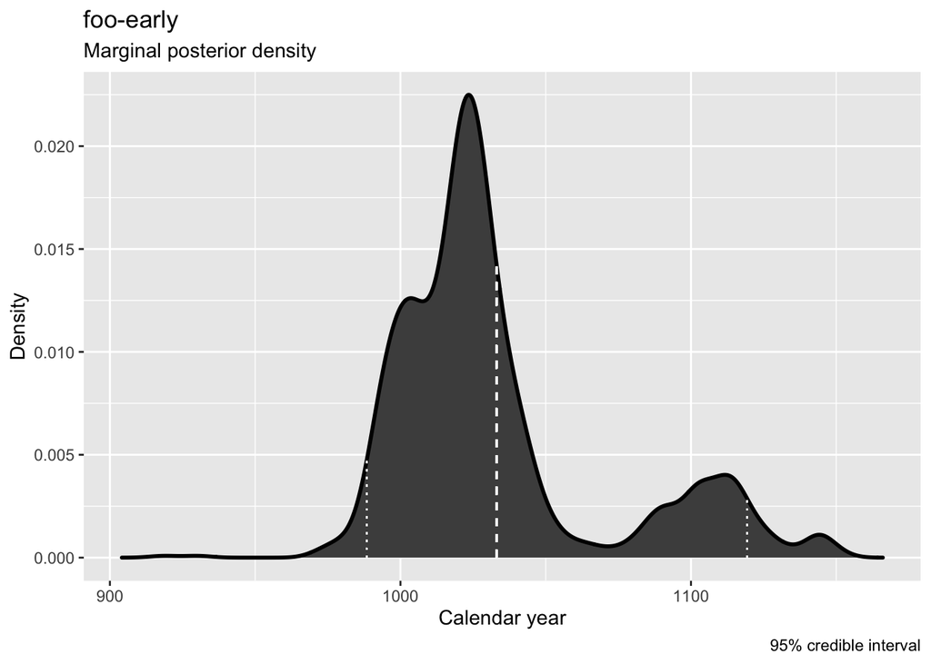

```r
## reproduce the marginal plot object
oxc.mar.rep <- reproduce(oxc.mar)
```

```r
## check for object identity returns TRUE
identical(oxc.mar.rep, oxc.mar)
```

```
[1] TRUE
```

## Objects Are Data Frames

The objects returned by the `read_*()` functions behave like data frames. The new function, `multi_marginal_statistics`, expects a data frame as its first argument. When passed the `oxc` object, it returns an object with various summary statistics of the marginals, as if it had been passed a standard data frame.

```r
oxc.stats <- multi_marginal_statistics(oxc)
oxc.stats$statistics
```

```
          mean sd  min   q1 median   q3  max ci.inf ci.sup
foo-early 1033 37  919 1010   1023 1038 1152    988   1119
foo-late  1126 49 1028 1081   1131 1164 1253   1044   1207
```

## Use Cases

The ability to reproduce an `ArchaeoPhases` analysis might find several uses.

One use case is when work on a project is interrupted. In this use case, objects produced during an earlier session and saved to disk can be read into the new `R` session. The `reproduce` methods of the objects will indicate whether or not the Bayesian calibration output is still available, and if so, whether or not it has changed.

Another use case is a collaboration where one might wish to distribute an MCMC file and the `R` code required to make an informative plot. An email message with the MCMC file and the saved `ArchaeoPhases` object attached is a reasonable way this might be accomplished. In this situation, the recipient can point the `reproduce()` function to the local MCMC file and verify that the analysis carried out by the sender can actually be reproduced.

A third use case is one you should know how to avoid. The S3 objects produced by ArchaeoPhases can be manipulated to include malicious code and an unscrupulous scoundrel might intend to harm you in this way. The best defense is, as usual, to choose trustworthy collaborators and not try to reproduce objects from unknown sources. In any event, a simple way to check for malicious code is to inspect the `call` attribute of the object, as shown in the following source code block. If the call looks good, then all should be well.

```r
attr(oxc.mar, "call")
```

```
marginal_plot(data = oxc)
```